# Validation v5: First Pass Fixation Position (FPFP)

Auto-generated validation report

2026-04-29

# 1. Introduction

This is the fifth validation report comparing **fixated** against **analyzeeyedry** on `C1L1.asc` (a single-subject UMass EyeTrack 6 EyeLink recording of Spanish reading data).

The primary goal of this report is to validate the **First Pass Fixation Position (FPFP)** computed by fixated’s new `get_landing_info()` function against the **First Pass Landing Position (`fplp`)** computed by analyzeeyedry (eyedry analysis 11).

## What is FPFP / fplp?

Both measures capture *where* within a word the eye first landed during the first pass (before making a rightward exit or a regression out of the word). Only the first fixation that passes the `shorttime` / `longtime` validity checks is used — short fixations (duration ≤ `shorttime`) are skipped, and a long fixation (duration > `longtime`) discards the value (returning `NA`).

**analyzeeyedry (`fplp`):** Returns the 0-indexed character position (from the start of the word/region) of the first valid first-pass fixation. Character positions are assigned by comparing the fixation’s pixel x coordinate against the right-pixel-boundary of each character from the `REGION CHAR` ASC messages.

**fixated (`fixated_char`):** `get_landing_info()` computes `word_proportion = (avg_x − x_start) / (x_end − x_start)` and then `fixated_char = floor(N × word_proportion) + 1` where `N` is the number of characters in the word (assuming a monospace font). To compare with analyzeeyedry’s 0-indexed `fplp`, we use **`fixated_char − 1`**.

The analysis uses the same parameter set as v4 (`shorttime = 80`, `longtime = 800`, `ttcutoff = 4000`, `truncate_at_display_on = TRUE`).

# 2. Setup

```r
pkg_root          <- file.path(getwd(), "..")
analyzeeyedry_dir <- file.path(getwd(), "analyzeeyedry")

if (!requireNamespace("analyzeeyedry", quietly = TRUE)) {
  install.packages(analyzeeyedry_dir, repos = NULL, type = "source")
}
if (!requireNamespace("fixated", quietly = TRUE)) {
  install.packages(pkg_root, repos = NULL, type = "source")
}

library(analyzeeyedry)
library(fixated)
library(dplyr)
library(ggplot2)
library(tidyr)
library(knitr)

ASC_FILE  <- file.path(pkg_root, "data_to_incorporate", "C1L1.asc")
SHORTTIME <- 80L
LONGTIME  <- 800L
TTCUTOFF  <- 4000L

stopifnot(file.exists(ASC_FILE))
cat("ASC file:", ASC_FILE, "\n")
```

```
## ASC file: /home/runner/work/fixated/fixated/validation/../data_to_incorporate/C1L1.asc
```

```r
cat("fixated version:", as.character(packageVersion("fixated")), "\n")
```

```
## fixated version: 0.1.0
```

```r
cat("analyzeeyedry version:", as.character(packageVersion("analyzeeyedry")), "\n")
```

```
## analyzeeyedry version: 0.1.0
```

# 3. Parse C1L1.asc with `read_eyetrack_asc()`

```r
et <- read_eyetrack_asc(ASC_FILE, trial_pattern = "^[A-Za-z]")
cat(sprintf("Parsed %d trials\n", nrow(et$trial_db)))
```

```
## Parsed 175 trials
```

```r
cat(sprintf("Fixations: %d rows\n", nrow(et$fixations)))
```

```
## Fixations: 3283 rows
```

```r
cat(sprintf("Word boundaries: %d rows across %d trials\n",
            nrow(et$word_boundaries),
            n_distinct(et$word_boundaries$trial_nr)))
```

```
## Word boundaries: 2037 rows across 175 trials
```

# 4. analyzeeyedry reference analysis

```r
word_regions_edry <- asc_to_cnt(
  ASC_FILE, trial_pattern = "^[A-Za-z]",
  spillover_gap = 1L, spillover_size = 20L)
fix_edry   <- asc_to_fixations(ASC_FILE, subj = 1L, trial_pattern = "^[A-Za-z]")
fix_edry_r <- assign_regions_to_fixations(fix_edry, word_regions_edry)
nregmax_val <- max(word_regions_edry$nreg, na.rm = TRUE)

measures_edry <- compute_fixation_measures(
  fix_edry_r, word_regions_edry,
  shorttime = SHORTTIME, longtime = LONGTIME,
  ttcutoff  = TTCUTOFF,
  nregmax   = nregmax_val)
cat(sprintf("analyzeeyedry: measures for %d trials\n", nrow(measures_edry)))
```

```
## analyzeeyedry: measures for 175 trials
```

# 5. Compute fixated FPFP using `get_landing_info()`

This section shows how to compute the First Pass Fixation Position from `fixated`. The steps are:

1. Apply the same `truncate_at_display_on` pre-processing that `compute_eye_measures()` uses.
2. Call `get_landing_info()` to add `fixated_char` to every fixation.
3. For each trial × word, loop through the (time-sorted) fixations in the same order as the FFD algorithm to find the first valid first-pass fixation and record its `fixated_char`.

```r
# ---- Step 1: apply truncate_at_display_on filtering -------------------------
fix_raw <- et$fixations
tdb     <- et$trial_db

fix_filtered <- fix_raw |>
  dplyr::left_join(
    tdb[, c("trial_nr", "t_display_on", "t_display_off")],
    by = "trial_nr") |>
  dplyr::filter(end_time > t_display_on) |>       # drop pre-display-onset fixes
  dplyr::mutate(
    straddle   = start_time <= t_display_on,
    start_time = dplyr::if_else(straddle, t_display_on, start_time),
    duration   = end_time - start_time            # recompute for straddlers
  ) |>
  dplyr::select(-t_display_on, -t_display_off, -straddle)

cat(sprintf("Fixations after display-on filter: %d (raw: %d)\n",
            nrow(fix_filtered), nrow(fix_raw)))
```

```
## Fixations after display-on filter: 2572 (raw: 3283)
```

```r
# ---- Step 2: add landing info (word_id, word_proportion, fixated_char) ------
fix_land <- get_landing_info(fix_filtered, et$word_boundaries)
cat(sprintf("Fixations with word assignment: %d / %d\n",
            sum(!is.na(fix_land$word_id)), nrow(fix_land)))
```

```
## Fixations with word assignment: 2513 / 2572
```

```r
# ---- Step 3: for each trial × word, extract FPFP ----------------------------
# Mirrors the FFD loop in .compute_trial_measures() but records fixated_char
# (converted to 0-indexed) instead of duration.

compute_fpfp <- function(fix_land, word_boundaries,
                          shorttime = 80L, longtime = 800L) {
  trials <- sort(unique(fix_land$trial_nr))
  result_rows <- vector("list", length(trials))
  ri <- 1L

  for (tr in trials) {
    # Time-sorted fixations for this trial
    tf <- fix_land[fix_land$trial_nr == tr, ]
    tf <- tf[order(tf$start_time), ]

    # Word boundaries for this trial
    wb_tr <- word_boundaries[word_boundaries$trial_nr == tr, ]

    for (w in sort(unique(wb_tr$word_id))) {
      roi_row <- wb_tr[wb_tr$word_id == w, ]
      if (nrow(roi_row) == 0L) next

      x_s <- roi_row$x_start[[1L]]
      x_e <- roi_row$x_end[[1L]]

      px    <- tf$avg_x
      dur   <- tf$duration
      fc    <- tf$fixated_char          # 1-indexed; NA when outside word
      n_fix <- nrow(tf)

      in_r   <- px >= x_s & px <= x_e
      past_r <- px >  x_e
      is_sht <- dur <= shorttime
      is_lng <- dur >  longtime

      fpfp_val <- NA_integer_
      for (i in seq_len(n_fix)) {
        if (past_r[i] && !is_sht[i]) break         # non-short rightward exit
        if (in_r[i]) {
          if (is_lng[i]) break                      # long fixation: discard
          if (is_sht[i]) next                       # short fixation: skip
          if (!is.na(fc[i])) {
            fpfp_val <- as.integer(fc[i]) - 1L      # convert to 0-indexed
          }
          break                                     # first valid fix found
        }
      }

      result_rows[[ri]] <- data.frame(
        trial_nr = tr,
        word_id  = as.integer(w),
        fpfp_fix = fpfp_val,
        stringsAsFactors = FALSE)
      ri <- ri + 1L
    }
  }

  dplyr::bind_rows(result_rows[seq_len(ri - 1L)])
}

fpfp_fix <- compute_fpfp(fix_land, et$word_boundaries,
                          shorttime = SHORTTIME, longtime = LONGTIME)

cat(sprintf("FPFP computed for %d trial × word pairs\n", nrow(fpfp_fix)))
```

```
## FPFP computed for 2037 trial × word pairs
```

```r
cat(sprintf("Non-NA FPFP values: %d\n", sum(!is.na(fpfp_fix$fpfp_fix))))
```

```
## Non-NA FPFP values: 1191
```

# 6. Reshape analyzeeyedry output

```r
trial_key <- dplyr::tibble(
  trial_nr = seq_len(nrow(et$trial_db)),
  cond     = et$trial_db$cond,
  item     = et$trial_db$item)

pivot_edry_long <- function(wide_df, trial_key,
                             measures = c("ff","fp","tt","gp","oreg","ireg",
                                          "pfix","nfix","sp","fplp")) {
  meas_pat  <- paste0("^(", paste(measures, collapse="|"), ")_R\\d+$")
  meas_cols <- names(wide_df)[grepl(meas_pat, names(wide_df))]
  long <- wide_df |>
    tidyr::pivot_longer(cols = dplyr::all_of(meas_cols),
                        names_to  = c("measure","word_id"),
                        names_pattern = "^(.+)_R(\\d+)$",
                        values_to = "value") |>
    dplyr::mutate(word_id = as.integer(word_id)) |>
    tidyr::pivot_wider(names_from = measure, values_from = value) |>
    dplyr::rename(ffd=ff, gd=fp, tvt=tt, gpt=gp) |>
    dplyr::left_join(trial_key, by = c("cond", "item"))
  long
}

edry_long <- pivot_edry_long(measures_edry, trial_key)
cat("analyzeeyedry long format:", nrow(edry_long), "rows\n")
```

```
## analyzeeyedry long format: 4025 rows
```

# 7. Merge and compare

```r
compare_v5 <- edry_long |>
  dplyr::select(trial_nr, cond, item, word_id,
                ffd_edry=ffd, gd_edry=gd, gpt_edry=gpt, tvt_edry=tvt,
                oreg_edry=oreg, ireg_edry=ireg, pfix_edry=pfix,
                nfix_edry=nfix, sp_edry=sp, fplp_edry=fplp) |>
  dplyr::inner_join(
    fpfp_fix |>
      dplyr::rename(fpfp_fix = fpfp_fix),
    by = c("trial_nr","word_id")) |>
  dplyr::arrange(trial_nr, word_id)

cat(sprintf("Comparison table: %d rows\n", nrow(compare_v5)))
```

```
## Comparison table: 2037 rows
```

```r
cat(sprintf("Rows with both FPLP values non-NA: %d\n",
            sum(!is.na(compare_v5$fplp_edry) & !is.na(compare_v5$fpfp_fix))))
```

```
## Rows with both FPLP values non-NA: 1188
```

# 8. Agreement analysis

## 8.1 Summary statistics

```r
full_summary <- function(df, col_edry, col_fix, label) {
  d    <- df[[col_fix]] - df[[col_edry]]
  ref  <- pmax(abs(df[[col_edry]]), 1)
  re   <- abs(d) / ref
  both <- !is.na(df[[col_edry]]) & !is.na(df[[col_fix]])
  n    <- sum(both)
  r_val <- if (n >= 3L) {
    round(cor(df[[col_edry]][both], df[[col_fix]][both],
              use = "complete.obs"), 3)
  } else NA_real_
  data.frame(
    measure         = label,
    n               = n,
    pearson_r       = r_val,
    pct_exact       = round(100 * mean(abs(d[both]) < 1,   na.rm=TRUE), 1),
    pct_1char       = round(100 * mean(abs(d[both]) <= 1,  na.rm=TRUE), 1),
    pct_2char       = round(100 * mean(abs(d[both]) <= 2,  na.rm=TRUE), 1),
    mean_abs_diff   = round(mean(abs(d[both]), na.rm=TRUE), 2),
    median_abs_diff = round(median(abs(d[both]), na.rm=TRUE), 2),
    stringsAsFactors = FALSE
  )
}

summary_tbl <- full_summary(compare_v5, "fplp_edry", "fpfp_fix", "FPFP (chars)")
knitr::kable(summary_tbl,
             col.names = c("Measure","N","r",
                           "% exact","% ≤1 char","% ≤2 chars",
                           "Mean |diff| (chars)","Median |diff| (chars)"),
             caption = "v5: agreement between fixated FPFP and analyzeeyedry fplp.")
```

v5: agreement between fixated FPFP and analyzeeyedry fplp.

| Measure | N | r | % exact | % ≤1 char | % ≤2 chars | Mean \|diff\| (chars) | Median \|diff\| (chars) |
| --- | --- | --- | --- | --- | --- | --- | --- |
| FPFP (chars) | 1188 | 0.873 | 98.5 | 98.9 | 98.9 | 0.1 | 0 |

## 8.2 Scatter plot

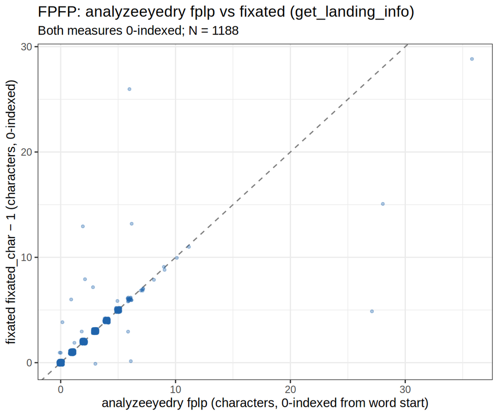

```r
plot_df <- compare_v5 |>
  dplyr::filter(!is.na(fplp_edry), !is.na(fpfp_fix))

ggplot(plot_df, aes(x = fplp_edry, y = fpfp_fix)) +
  geom_abline(slope = 1, intercept = 0, linetype = "dashed", colour = "grey50") +
  geom_jitter(alpha = 0.35, size = 0.9, colour = "#2166ac",
              width = 0.2, height = 0.2) +
  labs(title = "FPFP: analyzeeyedry fplp vs fixated (get_landing_info)",
       subtitle = paste0("Both measures 0-indexed; N = ", nrow(plot_df)),
       x = "analyzeeyedry fplp (characters, 0-indexed from word start)",
       y = "fixated fixated_char − 1 (characters, 0-indexed)") +
  theme_bw(base_size = 11)
```

## 8.3 Cross-tabulation of FPFP values

```r
both_known <- compare_v5 |>
  dplyr::filter(!is.na(fplp_edry), !is.na(fpfp_fix))

ct <- table(edry = both_known$fplp_edry,
            fixated = both_known$fpfp_fix,
            useNA = "ifany")
cat("Cross-tabulation of fplp (analyzeeyedry) vs fpfp_fix (fixated):\n")
```

```
## Cross-tabulation of fplp (analyzeeyedry) vs fpfp_fix (fixated):
```

```r
print(ct)
```

```
##     fixated
## edry   0   1   2   3   4   5   6   7   8   9  10  11  13  15  26  29
##   0  277   2   0   0   1   0   0   0   0   0   0   0   0   0   0   0
##   1    0 253   1   0   0   0   1   0   0   0   0   0   0   0   0   0
##   2    0   0 237   1   0   0   0   0   1   0   0   0   1   0   0   0
##   3    1   0   0 188   0   0   0   1   0   0   0   0   0   0   0   0
##   4    0   0   0   0 118   0   0   0   0   0   0   0   0   0   0   0
##   5    0   0   0   0   0  66   1   0   0   0   0   0   0   0   0   0
##   6    1   0   0   1   0   0  21   0   0   0   0   0   1   0   1   0
##   7    0   0   0   0   0   0   0   5   0   0   0   0   0   0   0   0
##   8    0   0   0   0   0   0   0   0   1   0   0   0   0   0   0   0
##   9    0   0   0   0   0   0   0   0   0   2   0   0   0   0   0   0
##   10   0   0   0   0   0   0   0   0   0   0   1   0   0   0   0   0
##   11   0   0   0   0   0   0   0   0   0   0   0   1   0   0   0   0
##   27   0   0   0   0   0   1   0   0   0   0   0   0   0   0   0   0
##   28   0   0   0   0   0   0   0   0   0   0   0   0   0   1   0   0
##   36   0   0   0   0   0   0   0   0   0   0   0   0   0   0   0   1
```

```r
n_both  <- nrow(both_known)
n_match <- sum(both_known$fplp_edry == both_known$fpfp_fix, na.rm = TRUE)
cat(sprintf("\nExact match: %d / %d (%.1f%%)\n",
            n_match, n_both, 100 * n_match / max(n_both, 1L)))
```

```
##
## Exact match: 1170 / 1188 (98.5%)
```

## 8.4 Distribution of absolute differences

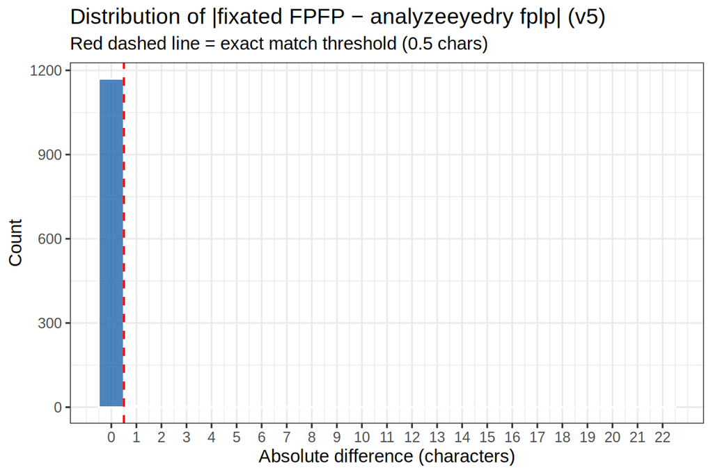

```r
diff_df <- compare_v5 |>
  dplyr::filter(!is.na(fplp_edry), !is.na(fpfp_fix)) |>
  dplyr::mutate(abs_diff = abs(fpfp_fix - fplp_edry))

ggplot(diff_df, aes(x = abs_diff)) +
  geom_histogram(binwidth = 1, fill = "#2166ac", colour = "white", alpha = 0.8) +
  geom_vline(xintercept = 0.5, linetype = "dashed", colour = "red",
             linewidth = 0.6) +
  scale_x_continuous(breaks = 0:max(diff_df$abs_diff, na.rm = TRUE)) +
  labs(title = "Distribution of |fixated FPFP − analyzeeyedry fplp| (v5)",
       subtitle = "Red dashed line = exact match threshold (0.5 chars)",
       x = "Absolute difference (characters)", y = "Count") +
  theme_bw(base_size = 11)
```

## 8.5 Cases where FPFP disagrees: inspection

```r
disagree <- compare_v5 |>
  dplyr::filter(!is.na(fplp_edry), !is.na(fpfp_fix),
                fplp_edry != fpfp_fix) |>
  dplyr::mutate(diff = fpfp_fix - fplp_edry) |>
  dplyr::select(trial_nr, cond, item, word_id, fplp_edry, fpfp_fix, diff) |>
  dplyr::arrange(abs(diff) |> desc())

cat(sprintf("%d rows where FPFP values differ:\n", nrow(disagree)))
```

```
## 18 rows where FPFP values differ:
```

```r
if (nrow(disagree) > 0L) {
  print(head(disagree, 30))
}
```

```
## # A tibble: 18 × 7
##    trial_nr  cond  item word_id fplp_edry fpfp_fix  diff
##       <int> <int> <int>   <int>     <dbl>    <int> <dbl>
##  1       70    12   123       6        27        5   -22
##  2       40    12    36       8         6       26    20
##  3       22    12     2       4        28       15   -13
##  4       57    12    96       7         2       13    11
##  5       28    12    13       4         6       13     7
##  6      136    11    38       4        36       29    -7
##  7       78    12    61       7         2        8     6
##  8       79     1    97       6         6        0    -6
##  9      107    11   116       7         1        6     5
## 10        8   200     6       6         0        4     4
## 11      116    11     9       6         3        7     4
## 12       79     1    97       7         3        0    -3
## 13       82     2    56      11         6        3    -3
## 14      108     1   119       3         5        6     1
## 15      162     2    18       8         1        2     1
## 16      163     1    29       4         2        3     1
## 17      169     1   111      14         0        1     1
## 18      175     1   105      13         0        1     1
```

# 9. NA comparison

```r
compare_v5 |>
  dplyr::mutate(
    edry_na = is.na(fplp_edry),
    fix_na  = is.na(fpfp_fix)
  ) |>
  dplyr::count(edry_na, fix_na) |>
  dplyr::mutate(
    status = dplyr::case_when(
      !edry_na & !fix_na  ~ "Both non-NA",
      !edry_na &  fix_na  ~ "Only analyzeeyedry has value",
      edry_na  & !fix_na  ~ "Only fixated has value",
      TRUE                ~ "Both NA"
    )
  ) |>
  dplyr::select(status, n) |>
  knitr::kable(caption = "NA agreement between analyzeeyedry fplp and fixated FPFP")
```

NA agreement between analyzeeyedry fplp and fixated FPFP

| status | n |
| --- | --- |
| Both non-NA | 1188 |
| Only analyzeeyedry has value | 66 |
| Only fixated has value | 3 |
| Both NA | 780 |

# 10. Discussion

## Sources of disagreement

**Proportional vs character-boundary interpolation**: analyzeeyedry uses the character bounding boxes from `REGION CHAR` messages to determine exactly which character the fixation falls on (by finding the first character whose right pixel boundary exceeds the fixation’s pixel x). `fixated` uses `word_proportion = (avg_x − x_start) / (x_end − x_start)` and assumes equally- spaced characters (`fixated_char = floor(N × word_proportion) + 1`).

When characters in the display are not equally wide (e.g., a proportional font, or characters with different widths like `i` vs `m`), the two methods will disagree. Even for monospace fonts, rounding differences at character boundaries can cause off-by-one disagreements.

**Region boundary differences**: `fixated` builds word pixel boundaries by merging the `REGION CHAR` bounding boxes for all non-space characters in a word. analyzeeyedry converts the character-grid position back to the word start using the `start_R{k}` values. Edge fixations (near a word boundary) may be assigned to different words by the two systems, producing FPFP disagreements.